# Risk Factor Analysis

## Outcome Variable

**Outcome Variable:** stunted

## Predictor Variables

**Intervention Variable:** hfoodsec

**Adjustment Set:**

- arm
- sex
- W_mage
- meducyrs
- feducyrs
- hhwealth_quart
- vagbrth
- W_nrooms
- W_nchldlt5
- brthmon
- W_parity
- impfloor
- impsan
- safeh20
- delta_W_mage
- delta_meducyrs
- delta_feducyrs
- delta_hhwealth_quart
- delta_vagbrth
- delta_W_nrooms
- delta_W_nchldlt5
- delta_brthmon
- delta_W_parity
- delta_impfloor
- delta_impsan
- delta_safeh20

## Stratifying Variables

The analysis was stratified on these variable(s):

- agecat
- studyid
- country

## Data Summary

| agecat | studyid | country | hfoodsec | stunted | n_cell | n |
| --- | --- | --- | --- | --- | --- | --- |
| Birth | ki0047075b-MAL-ED | BANGLADESH | Food Secure | 0 | 133 | 188 |
| Birth | ki0047075b-MAL-ED | BANGLADESH | Food Secure | 1 | 24 | 188 |
| Birth | ki0047075b-MAL-ED | BANGLADESH | Mildly Food Insecure | 0 | 3 | 188 |
| Birth | ki0047075b-MAL-ED | BANGLADESH | Mildly Food Insecure | 1 | 1 | 188 |
| Birth | ki0047075b-MAL-ED | BANGLADESH | Food Insecure | 0 | 23 | 188 |
| Birth | ki0047075b-MAL-ED | BANGLADESH | Food Insecure | 1 | 4 | 188 |
| Birth | ki0047075b-MAL-ED | BRAZIL | Food Secure | 0 | 0 | 105 |
| Birth | ki0047075b-MAL-ED | BRAZIL | Food Secure | 1 | 0 | 105 |
| Birth | ki0047075b-MAL-ED | BRAZIL | Mildly Food Insecure | 0 | 10 | 105 |
| Birth | ki0047075b-MAL-ED | BRAZIL | Mildly Food Insecure | 1 | 1 | 105 |
| Birth | ki0047075b-MAL-ED | BRAZIL | Food Insecure | 0 | 84 | 105 |
| Birth | ki0047075b-MAL-ED | BRAZIL | Food Insecure | 1 | 10 | 105 |
| Birth | ki0047075b-MAL-ED | INDIA | Food Secure | 0 | 133 | 170 |
| Birth | ki0047075b-MAL-ED | INDIA | Food Secure | 1 | 21 | 170 |
| Birth | ki0047075b-MAL-ED | INDIA | Mildly Food Insecure | 0 | 2 | 170 |
| Birth | ki0047075b-MAL-ED | INDIA | Mildly Food Insecure | 1 | 0 | 170 |
| Birth | ki0047075b-MAL-ED | INDIA | Food Insecure | 0 | 11 | 170 |
| Birth | ki0047075b-MAL-ED | INDIA | Food Insecure | 1 | 3 | 170 |
| Birth | ki0047075b-MAL-ED | NEPAL | Food Secure | 0 | 70 | 98 |
| Birth | ki0047075b-MAL-ED | NEPAL | Food Secure | 1 | 6 | 98 |
| Birth | ki0047075b-MAL-ED | NEPAL | Mildly Food Insecure | 0 | 9 | 98 |
| Birth | ki0047075b-MAL-ED | NEPAL | Mildly Food Insecure | 1 | 0 | 98 |
| Birth | ki0047075b-MAL-ED | NEPAL | Food Insecure | 0 | 10 | 98 |
| Birth | ki0047075b-MAL-ED | NEPAL | Food Insecure | 1 | 3 | 98 |
| Birth | ki0047075b-MAL-ED | PERU | Food Secure | 0 | 22 | 107 |
| Birth | ki0047075b-MAL-ED | PERU | Food Secure | 1 | 5 | 107 |
| Birth | ki0047075b-MAL-ED | PERU | Mildly Food Insecure | 0 | 22 | 107 |
| Birth | ki0047075b-MAL-ED | PERU | Mildly Food Insecure | 1 | 3 | 107 |
| Birth | ki0047075b-MAL-ED | PERU | Food Insecure | 0 | 50 | 107 |
| Birth | ki0047075b-MAL-ED | PERU | Food Insecure | 1 | 5 | 107 |

[output cut: 162 more lines]

The following strata were considered:

- agecat: 24 months, studyid: ki0047075b-MAL-ED, country: BANGLADESH
- agecat: 24 months, studyid: ki0047075b-MAL-ED, country: BRAZIL
- agecat: 24 months, studyid: ki0047075b-MAL-ED, country: INDIA
- agecat: 24 months, studyid: ki0047075b-MAL-ED, country: NEPAL
- agecat: 24 months, studyid: ki0047075b-MAL-ED, country: PERU
- agecat: 24 months, studyid: ki0047075b-MAL-ED, country: SOUTH AFRICA
- agecat: 24 months, studyid: ki1017093-NIH-Birth, country: BANGLADESH
- agecat: 24 months, studyid: ki1017093c-NIH-Crypto, country: BANGLADESH
- agecat: 24 months, studyid: ki1113344-GMS-Nepal, country: NEPAL
- agecat: 24 months, studyid: kiGH5241-JiVitA-3, country: BANGLADESH
- agecat: 24 months, studyid: kiGH5241-JiVitA-4, country: BANGLADESH
- agecat: 6 months, studyid: ki0047075b-MAL-ED, country: BANGLADESH
- agecat: 6 months, studyid: ki0047075b-MAL-ED, country: BRAZIL
- agecat: 6 months, studyid: ki0047075b-MAL-ED, country: INDIA
- agecat: 6 months, studyid: ki0047075b-MAL-ED, country: NEPAL
- agecat: 6 months, studyid: ki0047075b-MAL-ED, country: PERU
- agecat: 6 months, studyid: ki0047075b-MAL-ED, country: SOUTH AFRICA
- agecat: 6 months, studyid: ki1017093-NIH-Birth, country: BANGLADESH
- agecat: 6 months, studyid: ki1017093c-NIH-Crypto, country: BANGLADESH
- agecat: 6 months, studyid: ki1113344-GMS-Nepal, country: NEPAL
- agecat: 6 months, studyid: kiGH5241-JiVitA-3, country: BANGLADESH
- agecat: 6 months, studyid: kiGH5241-JiVitA-4, country: BANGLADESH
- agecat: Birth, studyid: ki0047075b-MAL-ED, country: BANGLADESH
- agecat: Birth, studyid: ki0047075b-MAL-ED, country: BRAZIL
- agecat: Birth, studyid: ki0047075b-MAL-ED, country: INDIA
- agecat: Birth, studyid: ki0047075b-MAL-ED, country: NEPAL
- agecat: Birth, studyid: ki0047075b-MAL-ED, country: PERU
- agecat: Birth, studyid: ki0047075b-MAL-ED, country: SOUTH AFRICA
- agecat: Birth, studyid: ki1017093-NIH-Birth, country: BANGLADESH
- agecat: Birth, studyid: ki1017093c-NIH-Crypto, country: BANGLADESH
- agecat: Birth, studyid: kiGH5241-JiVitA-3, country: BANGLADESH
- agecat: Birth, studyid: kiGH5241-JiVitA-4, country: BANGLADESH

### Dropped Strata

Some strata were dropped due to rare outcomes:

- agecat: Birth, studyid: ki0047075b-MAL-ED, country: BANGLADESH
- agecat: Birth, studyid: ki0047075b-MAL-ED, country: BRAZIL
- agecat: Birth, studyid: ki0047075b-MAL-ED, country: INDIA
- agecat: Birth, studyid: ki0047075b-MAL-ED, country: NEPAL
- agecat: Birth, studyid: ki0047075b-MAL-ED, country: PERU
- agecat: Birth, studyid: ki0047075b-MAL-ED, country: SOUTH AFRICA
- agecat: Birth, studyid: ki1017093-NIH-Birth, country: BANGLADESH
- agecat: Birth, studyid: ki1017093c-NIH-Crypto, country: BANGLADESH
- agecat: 6 months, studyid: ki0047075b-MAL-ED, country: BANGLADESH
- agecat: 6 months, studyid: ki0047075b-MAL-ED, country: BRAZIL
- agecat: 6 months, studyid: ki0047075b-MAL-ED, country: INDIA
- agecat: 6 months, studyid: ki0047075b-MAL-ED, country: NEPAL
- agecat: 6 months, studyid: ki0047075b-MAL-ED, country: SOUTH AFRICA
- agecat: 24 months, studyid: ki0047075b-MAL-ED, country: BANGLADESH
- agecat: 24 months, studyid: ki0047075b-MAL-ED, country: BRAZIL
- agecat: 24 months, studyid: ki0047075b-MAL-ED, country: INDIA
- agecat: 24 months, studyid: ki0047075b-MAL-ED, country: NEPAL

## Methods Detail

We’re interested in the causal parameters $E[Y_a]$ for all values of $a \in \mathcal{A}$. These parameters represent the mean outcome if, possibly contrary to fact, we intervened to set all units to have $A=a$. Under the randomization and positivity assumptions, these are identified by the statistical parameters $\psi_a=E_W[E_{Y|A,W}(Y|A=a,W)]$. In addition, we’re interested in the mean of $Y$, $E[Y]$ under no intervention (the observed mean). We will estimate these parameters by using SuperLearner to fit the relevant likelihood factors – $E_{Y|A,W}(Y|A=a,W)$ and $p(A=a|W)$, and then updating our likelihood fit using a joint TMLE.

For unadjusted analyses ($W=\{\}$), initial likelihoods were estimated using Lrnr_glm to estimate the simple $E(Y|A)$ and Lrnr_mean to estimate $p(A)$. For adjusted analyses, a small library containing Lrnr_glmnet, Lrnr_xgboost, and Lrnr_mean was used.

Having estimated these parameters, we will then use the delta method to estimate relative risks and attributable risks relative to a prespecified baseline level of $A$.

# Results Detail

## Results Plots

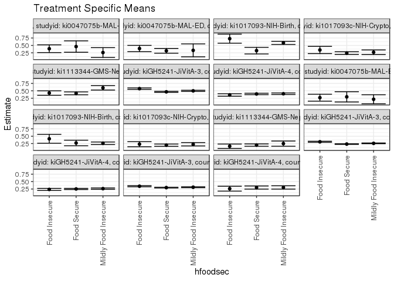

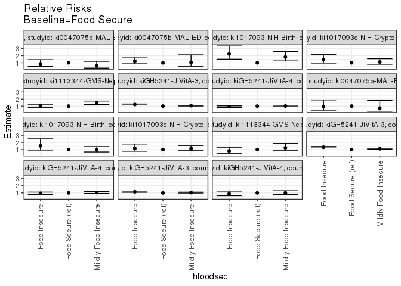

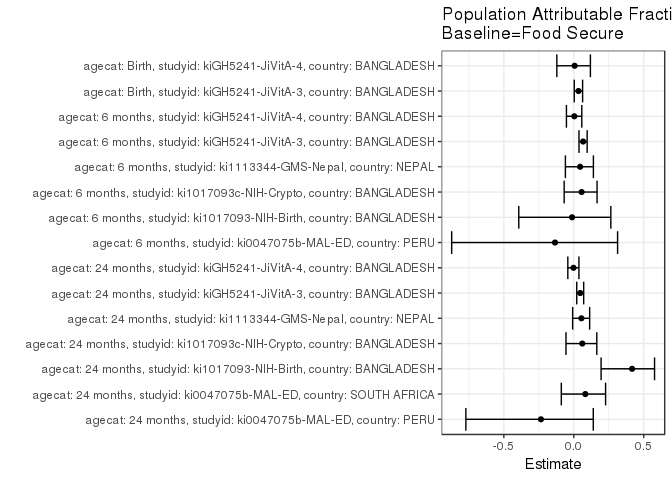

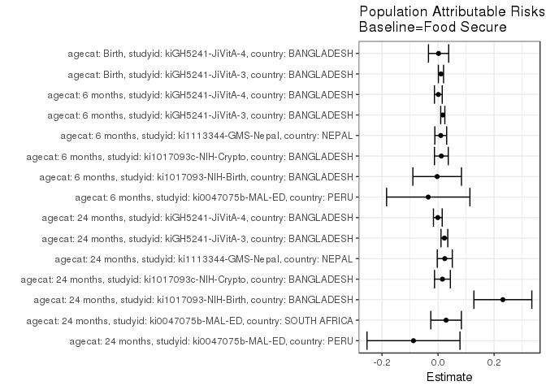

## Results Table

### Parameter: TSM

| agecat | studyid | country | intervention_level | baseline_level | estimate | ci_lower | ci_upper |
| --- | --- | --- | --- | --- | --- | --- | --- |
| Birth | kiGH5241-JiVitA-3 | BANGLADESH | Food Secure | NA | 0.2968981 | 0.2844175 | 0.3093787 |
| Birth | kiGH5241-JiVitA-3 | BANGLADESH | Mildly Food Insecure | NA | 0.3101137 | 0.2954712 | 0.3247562 |
| Birth | kiGH5241-JiVitA-3 | BANGLADESH | Food Insecure | NA | 0.3435783 | 0.3238655 | 0.3632910 |
| Birth | kiGH5241-JiVitA-4 | BANGLADESH | Food Secure | NA | 0.2997512 | 0.2469019 | 0.3526005 |
| Birth | kiGH5241-JiVitA-4 | BANGLADESH | Mildly Food Insecure | NA | 0.3024767 | 0.2468164 | 0.3581370 |
| Birth | kiGH5241-JiVitA-4 | BANGLADESH | Food Insecure | NA | 0.2612533 | 0.1793546 | 0.3431520 |
| 6 months | ki0047075b-MAL-ED | PERU | Food Secure | NA | 0.2962963 | 0.1232791 | 0.4693135 |
| 6 months | ki0047075b-MAL-ED | PERU | Mildly Food Insecure | NA | 0.2142857 | 0.0616124 | 0.3669590 |
| 6 months | ki0047075b-MAL-ED | PERU | Food Insecure | NA | 0.2678571 | 0.1513457 | 0.3843686 |
| 6 months | ki1017093-NIH-Birth | BANGLADESH | Food Secure | NA | 0.2713852 | 0.1778150 | 0.3649553 |
| 6 months | ki1017093-NIH-Birth | BANGLADESH | Mildly Food Insecure | NA | 0.2623078 | 0.2201117 | 0.3045039 |
| 6 months | ki1017093-NIH-Birth | BANGLADESH | Food Insecure | NA | 0.4131777 | 0.2639037 | 0.5624518 |
| 6 months | ki1017093c-NIH-Crypto | BANGLADESH | Food Secure | NA | 0.1980056 | 0.1602289 | 0.2357824 |
| 6 months | ki1017093c-NIH-Crypto | BANGLADESH | Mildly Food Insecure | NA | 0.2276027 | 0.1705888 | 0.2846167 |
| 6 months | ki1017093c-NIH-Crypto | BANGLADESH | Food Insecure | NA | 0.2308892 | 0.1441527 | 0.3176258 |
| 6 months | ki1113344-GMS-Nepal | NEPAL | Food Secure | NA | 0.2014247 | 0.1624034 | 0.2404459 |
| 6 months | ki1113344-GMS-Nepal | NEPAL | Mildly Food Insecure | NA | 0.2509129 | 0.1638019 | 0.3380239 |
| 6 months | ki1113344-GMS-Nepal | NEPAL | Food Insecure | NA | 0.1613634 | 0.0864626 | 0.2362641 |
| 6 months | kiGH5241-JiVitA-3 | BANGLADESH | Food Secure | NA | 0.2346609 | 0.2242660 | 0.2450559 |
| 6 months | kiGH5241-JiVitA-3 | BANGLADESH | Mildly Food Insecure | NA | 0.2590621 | 0.2468400 | 0.2712842 |
| 6 months | kiGH5241-JiVitA-3 | BANGLADESH | Food Insecure | NA | 0.3108830 | 0.2921444 | 0.3296216 |
| 6 months | kiGH5241-JiVitA-4 | BANGLADESH | Food Secure | NA | 0.2521038 | 0.2322041 | 0.2720036 |
| 6 months | kiGH5241-JiVitA-4 | BANGLADESH | Mildly Food Insecure | NA | 0.2626027 | 0.2390664 | 0.2861390 |
| 6 months | kiGH5241-JiVitA-4 | BANGLADESH | Food Insecure | NA | 0.2363430 | 0.2007690 | 0.2719171 |
| 24 months | ki0047075b-MAL-ED | PERU | Food Secure | NA | 0.4615385 | 0.2690159 | 0.6540610 |
| 24 months | ki0047075b-MAL-ED | PERU | Mildly Food Insecure | NA | 0.2592593 | 0.0931838 | 0.4253347 |
| 24 months | ki0047075b-MAL-ED | PERU | Food Insecure | NA | 0.3888889 | 0.2582528 | 0.5195249 |
| 24 months | ki0047075b-MAL-ED | SOUTH AFRICA | Food Secure | NA | 0.3178295 | 0.2373006 | 0.3983583 |
| 24 months | ki0047075b-MAL-ED | SOUTH AFRICA | Mildly Food Insecure | NA | 0.3333333 | 0.1150804 | 0.5515863 |
| 24 months | ki0047075b-MAL-ED | SOUTH AFRICA | Food Insecure | NA | 0.3950617 | 0.2883657 | 0.5017577 |
| 24 months | ki1017093-NIH-Birth | BANGLADESH | Food Secure | NA | 0.3235294 | 0.2122072 | 0.4348516 |
| 24 months | ki1017093-NIH-Birth | BANGLADESH | Mildly Food Insecure | NA | 0.5853659 | 0.5319876 | 0.6387441 |
| 24 months | ki1017093-NIH-Birth | BANGLADESH | Food Insecure | NA | 0.7272727 | 0.5751441 | 0.8794013 |
| 24 months | ki1017093c-NIH-Crypto | BANGLADESH | Food Secure | NA | 0.2411786 | 0.1952897 | 0.2870676 |
| 24 months | ki1017093c-NIH-Crypto | BANGLADESH | Mildly Food Insecure | NA | 0.2692553 | 0.1915961 | 0.3469146 |
| 24 months | ki1017093c-NIH-Crypto | BANGLADESH | Food Insecure | NA | 0.3462898 | 0.2246332 | 0.4679464 |
| 24 months | ki1113344-GMS-Nepal | NEPAL | Food Secure | NA | 0.4145419 | 0.3657160 | 0.4633679 |
| 24 months | ki1113344-GMS-Nepal | NEPAL | Mildly Food Insecure | NA | 0.6001108 | 0.5262371 | 0.6739846 |
| 24 months | ki1113344-GMS-Nepal | NEPAL | Food Insecure | NA | 0.4248432 | 0.3502325 | 0.4994539 |
| 24 months | kiGH5241-JiVitA-3 | BANGLADESH | Food Secure | NA | 0.4658872 | 0.4481085 | 0.4836658 |
| 24 months | kiGH5241-JiVitA-3 | BANGLADESH | Mildly Food Insecure | NA | 0.4986966 | 0.4784309 | 0.5189622 |
| 24 months | kiGH5241-JiVitA-3 | BANGLADESH | Food Insecure | NA | 0.5736354 | 0.5490321 | 0.5982386 |
| 24 months | kiGH5241-JiVitA-4 | BANGLADESH | Food Secure | NA | 0.3937947 | 0.3703184 | 0.4172709 |
| 24 months | kiGH5241-JiVitA-4 | BANGLADESH | Mildly Food Insecure | NA | 0.4012306 | 0.3742295 | 0.4282317 |
| 24 months | kiGH5241-JiVitA-4 | BANGLADESH | Food Insecure | NA | 0.3596990 | 0.3179195 | 0.4014785 |

### Parameter: E(Y)

| agecat | studyid | country | intervention_level | baseline_level | estimate | ci_lower | ci_upper |
| --- | --- | --- | --- | --- | --- | --- | --- |
| Birth | kiGH5241-JiVitA-3 | BANGLADESH | NA | NA | 0.3072590 | 0.2982359 | 0.3162822 |
| Birth | kiGH5241-JiVitA-4 | BANGLADESH | NA | NA | 0.3015873 | 0.2659035 | 0.3372711 |
| 6 months | ki0047075b-MAL-ED | PERU | NA | NA | 0.2612613 | 0.1791629 | 0.3433597 |
| 6 months | ki1017093-NIH-Birth | BANGLADESH | NA | NA | 0.2681564 | 0.2306532 | 0.3056597 |
| 6 months | ki1017093c-NIH-Crypto | BANGLADESH | NA | NA | 0.2097902 | 0.1799252 | 0.2396552 |
| 6 months | ki1113344-GMS-Nepal | NEPAL | NA | NA | 0.2110092 | 0.1767217 | 0.2452966 |
| 6 months | kiGH5241-JiVitA-3 | BANGLADESH | NA | NA | 0.2514834 | 0.2433398 | 0.2596271 |
| 6 months | kiGH5241-JiVitA-4 | BANGLADESH | NA | NA | 0.2530917 | 0.2387859 | 0.2673974 |
| 24 months | ki0047075b-MAL-ED | PERU | NA | NA | 0.3738318 | 0.2817277 | 0.4659358 |
| 24 months | ki0047075b-MAL-ED | SOUTH AFRICA | NA | NA | 0.3464912 | 0.2845889 | 0.4083936 |
| 24 months | ki1017093-NIH-Birth | BANGLADESH | NA | NA | 0.5547786 | 0.5076945 | 0.6018626 |
| 24 months | ki1017093c-NIH-Crypto | BANGLADESH | NA | NA | 0.2568093 | 0.2190047 | 0.2946140 |
| 24 months | ki1113344-GMS-Nepal | NEPAL | NA | NA | 0.4385246 | 0.3944543 | 0.4825949 |
| 24 months | kiGH5241-JiVitA-3 | BANGLADESH | NA | NA | 0.4885096 | 0.4750791 | 0.5019401 |
| 24 months | kiGH5241-JiVitA-4 | BANGLADESH | NA | NA | 0.3929813 | 0.3757719 | 0.4101908 |

### Parameter: RR

| agecat | studyid | country | intervention_level | baseline_level | estimate | ci_lower | ci_upper |
| --- | --- | --- | --- | --- | --- | --- | --- |
| Birth | kiGH5241-JiVitA-3 | BANGLADESH | Food Secure | Food Secure | 1.0000000 | 1.0000000 | 1.000000 |
| Birth | kiGH5241-JiVitA-3 | BANGLADESH | Mildly Food Insecure | Food Secure | 1.0445123 | 0.9823713 | 1.110584 |
| Birth | kiGH5241-JiVitA-3 | BANGLADESH | Food Insecure | Food Secure | 1.1572262 | 1.0776212 | 1.242712 |
| Birth | kiGH5241-JiVitA-4 | BANGLADESH | Food Secure | Food Secure | 1.0000000 | 1.0000000 | 1.000000 |
| Birth | kiGH5241-JiVitA-4 | BANGLADESH | Mildly Food Insecure | Food Secure | 1.0090924 | 0.7825701 | 1.301184 |
| Birth | kiGH5241-JiVitA-4 | BANGLADESH | Food Insecure | Food Secure | 0.8715670 | 0.6094559 | 1.246405 |
| 6 months | ki0047075b-MAL-ED | PERU | Food Secure | Food Secure | 1.0000000 | 1.0000000 | 1.000000 |
| 6 months | ki0047075b-MAL-ED | PERU | Mildly Food Insecure | Food Secure | 0.7232143 | 0.2878706 | 1.816924 |
| 6 months | ki0047075b-MAL-ED | PERU | Food Insecure | Food Secure | 0.9040179 | 0.4364671 | 1.872417 |
| 6 months | ki1017093-NIH-Birth | BANGLADESH | Food Secure | Food Secure | 1.0000000 | 1.0000000 | 1.000000 |
| 6 months | ki1017093-NIH-Birth | BANGLADESH | Mildly Food Insecure | Food Secure | 0.9665516 | 0.6605552 | 1.414298 |
| 6 months | ki1017093-NIH-Birth | BANGLADESH | Food Insecure | Food Secure | 1.5224773 | 0.9245365 | 2.507134 |
| 6 months | ki1017093c-NIH-Crypto | BANGLADESH | Food Secure | Food Secure | 1.0000000 | 1.0000000 | 1.000000 |
| 6 months | ki1017093c-NIH-Crypto | BANGLADESH | Mildly Food Insecure | Food Secure | 1.1494761 | 0.8394804 | 1.573944 |
| 6 months | ki1017093c-NIH-Crypto | BANGLADESH | Food Insecure | Food Secure | 1.1660741 | 0.7655382 | 1.776174 |
| 6 months | ki1113344-GMS-Nepal | NEPAL | Food Secure | Food Secure | 1.0000000 | 1.0000000 | 1.000000 |
| 6 months | ki1113344-GMS-Nepal | NEPAL | Mildly Food Insecure | Food Secure | 1.2456911 | 0.8370661 | 1.853792 |
| 6 months | ki1113344-GMS-Nepal | NEPAL | Food Insecure | Food Secure | 0.8011102 | 0.4843949 | 1.324906 |
| 6 months | kiGH5241-JiVitA-3 | BANGLADESH | Food Secure | Food Secure | 1.0000000 | 1.0000000 | 1.000000 |
| 6 months | kiGH5241-JiVitA-3 | BANGLADESH | Mildly Food Insecure | Food Secure | 1.1039849 | 1.0401609 | 1.171725 |
| 6 months | kiGH5241-JiVitA-3 | BANGLADESH | Food Insecure | Food Secure | 1.3248178 | 1.2305552 | 1.426301 |
| 6 months | kiGH5241-JiVitA-4 | BANGLADESH | Food Secure | Food Secure | 1.0000000 | 1.0000000 | 1.000000 |
| 6 months | kiGH5241-JiVitA-4 | BANGLADESH | Mildly Food Insecure | Food Secure | 1.0416451 | 0.9239232 | 1.174367 |
| 6 months | kiGH5241-JiVitA-4 | BANGLADESH | Food Insecure | Food Secure | 0.9374830 | 0.7924801 | 1.109018 |
| 24 months | ki0047075b-MAL-ED | PERU | Food Secure | Food Secure | 1.0000000 | 1.0000000 | 1.000000 |
| 24 months | ki0047075b-MAL-ED | PERU | Mildly Food Insecure | Food Secure | 0.5617284 | 0.2615430 | 1.206451 |
| 24 months | ki0047075b-MAL-ED | PERU | Food Insecure | Food Secure | 0.8425926 | 0.4931961 | 1.439513 |
| 24 months | ki0047075b-MAL-ED | SOUTH AFRICA | Food Secure | Food Secure | 1.0000000 | 1.0000000 | 1.000000 |
| 24 months | ki0047075b-MAL-ED | SOUTH AFRICA | Mildly Food Insecure | Food Secure | 1.0487805 | 0.5197306 | 2.116366 |
| 24 months | ki0047075b-MAL-ED | SOUTH AFRICA | Food Insecure | Food Secure | 1.2429991 | 0.8583073 | 1.800109 |
| 24 months | ki1017093-NIH-Birth | BANGLADESH | Food Secure | Food Secure | 1.0000000 | 1.0000000 | 1.000000 |
| 24 months | ki1017093-NIH-Birth | BANGLADESH | Mildly Food Insecure | Food Secure | 1.8093126 | 1.2674186 | 2.582897 |
| 24 months | ki1017093-NIH-Birth | BANGLADESH | Food Insecure | Food Secure | 2.2479339 | 1.5028032 | 3.362521 |
| 24 months | ki1017093c-NIH-Crypto | BANGLADESH | Food Secure | Food Secure | 1.0000000 | 1.0000000 | 1.000000 |
| 24 months | ki1017093c-NIH-Crypto | BANGLADESH | Mildly Food Insecure | Food Secure | 1.1164145 | 0.7908943 | 1.575914 |
| 24 months | ki1017093c-NIH-Crypto | BANGLADESH | Food Insecure | Food Secure | 1.4358228 | 0.9628839 | 2.141055 |
| 24 months | ki1113344-GMS-Nepal | NEPAL | Food Secure | Food Secure | 1.0000000 | 1.0000000 | 1.000000 |
| 24 months | ki1113344-GMS-Nepal | NEPAL | Mildly Food Insecure | Food Secure | 1.4476481 | 1.2225954 | 1.714128 |
| 24 months | ki1113344-GMS-Nepal | NEPAL | Food Insecure | Food Secure | 1.0248498 | 0.8307506 | 1.264299 |
| 24 months | kiGH5241-JiVitA-3 | BANGLADESH | Food Secure | Food Secure | 1.0000000 | 1.0000000 | 1.000000 |
| 24 months | kiGH5241-JiVitA-3 | BANGLADESH | Mildly Food Insecure | Food Secure | 1.0704235 | 1.0165634 | 1.127137 |
| 24 months | kiGH5241-JiVitA-3 | BANGLADESH | Food Insecure | Food Secure | 1.2312753 | 1.1655656 | 1.300689 |
| 24 months | kiGH5241-JiVitA-4 | BANGLADESH | Food Secure | Food Secure | 1.0000000 | 1.0000000 | 1.000000 |
| 24 months | kiGH5241-JiVitA-4 | BANGLADESH | Mildly Food Insecure | Food Secure | 1.0188827 | 0.9338926 | 1.111608 |
| 24 months | kiGH5241-JiVitA-4 | BANGLADESH | Food Insecure | Food Secure | 0.9134177 | 0.8038082 | 1.037974 |

### Parameter: PAR

| agecat | studyid | country | intervention_level | baseline_level | estimate | ci_lower | ci_upper |
| --- | --- | --- | --- | --- | --- | --- | --- |
| Birth | kiGH5241-JiVitA-3 | BANGLADESH | Food Secure | NA | 0.0103609 | 0.0011592 | 0.0195627 |
| Birth | kiGH5241-JiVitA-4 | BANGLADESH | Food Secure | NA | 0.0018361 | -0.0342284 | 0.0379006 |
| 6 months | ki0047075b-MAL-ED | PERU | Food Secure | NA | -0.0350350 | -0.1837366 | 0.1136665 |
| 6 months | ki1017093-NIH-Birth | BANGLADESH | Food Secure | NA | -0.0032287 | -0.0899583 | 0.0835008 |
| 6 months | ki1017093c-NIH-Crypto | BANGLADESH | Food Secure | NA | 0.0117846 | -0.0128289 | 0.0363981 |
| 6 months | ki1113344-GMS-Nepal | NEPAL | Food Secure | NA | 0.0095845 | -0.0115511 | 0.0307201 |
| 6 months | kiGH5241-JiVitA-3 | BANGLADESH | Food Secure | NA | 0.0168225 | 0.0094518 | 0.0241932 |
| 6 months | kiGH5241-JiVitA-4 | BANGLADESH | Food Secure | NA | 0.0009879 | -0.0129011 | 0.0148768 |
| 24 months | ki0047075b-MAL-ED | PERU | Food Secure | NA | -0.0877067 | -0.2536441 | 0.0782307 |
| 24 months | ki0047075b-MAL-ED | SOUTH AFRICA | Food Secure | NA | 0.0286618 | -0.0259150 | 0.0832385 |
| 24 months | ki1017093-NIH-Birth | BANGLADESH | Food Secure | NA | 0.2312491 | 0.1279008 | 0.3345975 |
| 24 months | ki1017093c-NIH-Crypto | BANGLADESH | Food Secure | NA | 0.0156307 | -0.0126278 | 0.0438892 |
| 24 months | ki1113344-GMS-Nepal | NEPAL | Food Secure | NA | 0.0239827 | -0.0028212 | 0.0507865 |
| 24 months | kiGH5241-JiVitA-3 | BANGLADESH | Food Secure | NA | 0.0226224 | 0.0105110 | 0.0347338 |
| 24 months | kiGH5241-JiVitA-4 | BANGLADESH | Food Secure | NA | -0.0008133 | -0.0164174 | 0.0147907 |

### Parameter: PAF

| agecat | studyid | country | intervention_level | baseline_level | estimate | ci_lower | ci_upper |
| --- | --- | --- | --- | --- | --- | --- | --- |
| Birth | kiGH5241-JiVitA-3 | BANGLADESH | Food Secure | NA | 0.0337205 | 0.0033504 | 0.0631651 |
| Birth | kiGH5241-JiVitA-4 | BANGLADESH | Food Secure | NA | 0.0060880 | -0.1210569 | 0.1188128 |
| 6 months | ki0047075b-MAL-ED | PERU | Food Secure | NA | -0.1340996 | -0.8728000 | 0.3132305 |
| 6 months | ki1017093-NIH-Birth | BANGLADESH | Food Secure | NA | -0.0120405 | -0.3931929 | 0.2648355 |
| 6 months | ki1017093c-NIH-Crypto | BANGLADESH | Food Secure | NA | 0.0561732 | -0.0686285 | 0.1663997 |
| 6 months | ki1113344-GMS-Nepal | NEPAL | Food Secure | NA | 0.0454222 | -0.0599241 | 0.1402981 |
| 6 months | kiGH5241-JiVitA-3 | BANGLADESH | Food Secure | NA | 0.0668931 | 0.0372713 | 0.0956035 |
| 6 months | kiGH5241-JiVitA-4 | BANGLADESH | Food Secure | NA | 0.0039032 | -0.0525132 | 0.0572956 |
| 24 months | ki0047075b-MAL-ED | PERU | Food Secure | NA | -0.2346154 | -0.7713345 | 0.1394764 |
| 24 months | ki0047075b-MAL-ED | SOUTH AFRICA | Food Secure | NA | 0.0827200 | -0.0891025 | 0.2274349 |
| 24 months | ki1017093-NIH-Birth | BANGLADESH | Food Secure | NA | 0.4168314 | 0.1952617 | 0.5773961 |
| 24 months | ki1017093c-NIH-Crypto | BANGLADESH | Food Secure | NA | 0.0608650 | -0.0557129 | 0.1645697 |
| 24 months | ki1113344-GMS-Nepal | NEPAL | Food Secure | NA | 0.0546895 | -0.0080284 | 0.1135051 |
| 24 months | kiGH5241-JiVitA-3 | BANGLADESH | Food Secure | NA | 0.0463091 | 0.0212020 | 0.0707721 |
| 24 months | kiGH5241-JiVitA-4 | BANGLADESH | Food Secure | NA | -0.0020697 | -0.0425718 | 0.0368589 |